# Performance Evaluation of Parallel QuickSort implementation

Jad Darrous

February 13, 2016

## Intro

In this document, a performance evaluation of three different implementations of the QuickSort algorithm is presented. The document compare between:

- Sequential implementation
- Parallel implementation (POSIX Threads)
- Built-in implementation (Libc)

## Testbed

For the hardware:

```
## Physical Processors count: 1
## Processor: Intel(R) Core(TM)2 Duo CPU E8400 @ 3.00GHz
## Processor architecture: unknown
## Number of cores: 2
## Threads per core: 2
## Hyper-Threading: Enabled
## Main memory: 8064276 kB
## Caches:
## L1d cache:             32K
## L1i cache:             32K
## L2 cache:              6144K
```

For the software:

```
## Operating system: GNU/Linux
## Distribution: Debian GNU/Linux 8.1 (jessie)
## Kernel version: 3.16.0-4-amd64
## Compiler version: g++ (Debian 4.9.2-10) 4.9.2
```

## Software spec.

- A fixed seed is used to guarantee that all replications are done on the same values.
- The elements type of arrays are double-precision floating-point.
- For measuring time, the function `clock_gettime` is used to get the current system time.
- The optimization level of the compiler is set to `O3`.

## Experiments

The experiments are conducted on three ranges of values:

- Small values: less than 1000

```
Design.1 <- fac.design(nfactors=2, replications=30, repeat.only=FALSE,
                     blocks=1, randomize=TRUE, seed=24625,
                     factor.names=list(size=(1:50)*20, tlevel=c(2:6)))
```

- Medium values: between 50000 and 1000000

```
Design.2 <- fac.design(nfactors=2, replications=15, repeat.only=FALSE,
                       blocks=1, randomize=TRUE, seed=24625,
                       factor.names=list(size=(1:20)*50000, tlevel=c(2:6)))
```

- Large values: between ${10}^{6}$ and ${10}^{7}$

```
Design.3 <- fac.design(nfactors=2, replications=5, repeat.only=FALSE,
                      blocks=1, randomize=TRUE, seed=24625,
                      factor.names=list(size=(1:10)*(10^6), tlevel=c(3:4)))
```

For each run, we do the measurements for each sorting function *three* times, in a random order, and take the average.

## Results

### Small values

For the small values, we observe a high variability of the parallel algorithm (with two threads), which can be explained by the high overhead of thread management compared to the actual job of comparing and swapping elements.

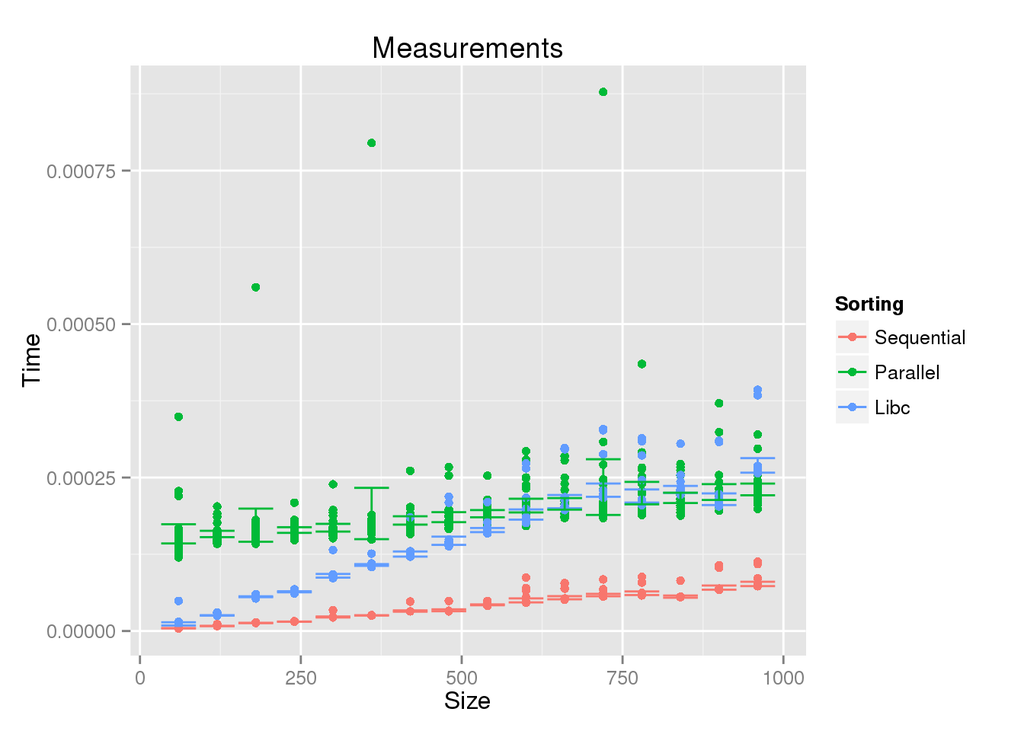

Focusing on the sequential and Libc implementation:

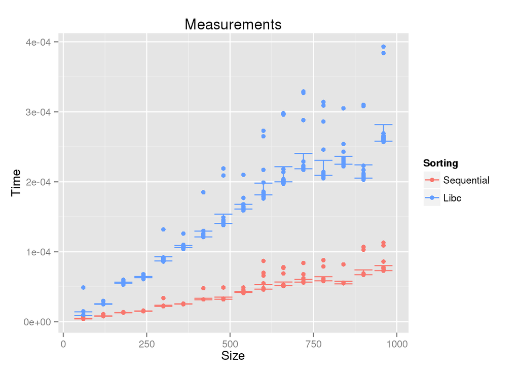

### Medium values

First plot of the data, 8 threads is used in the parallel version:

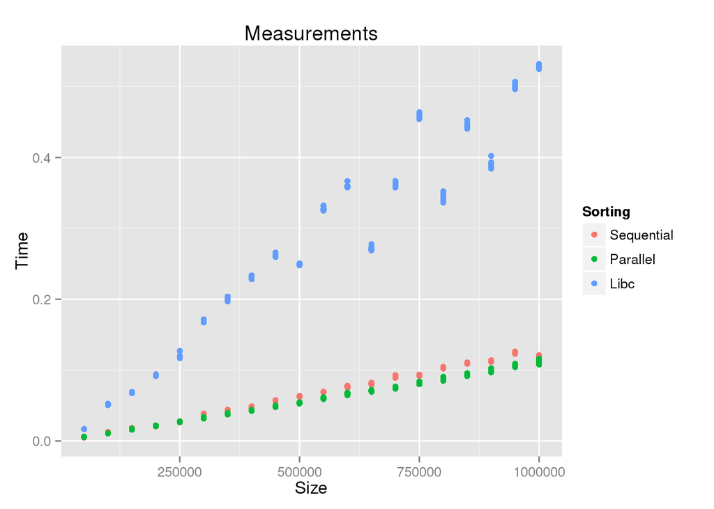

The LibC is worse than the two others, and the gap increases with the increased size. This mainly due to the comparison function calls, as it is shown by profiling.

Let’s focus on the sequential and parallel implementations:

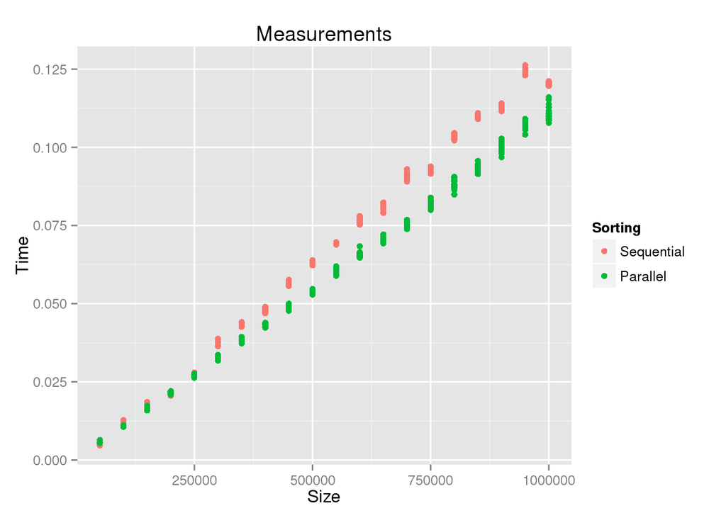

With the confidence interval:

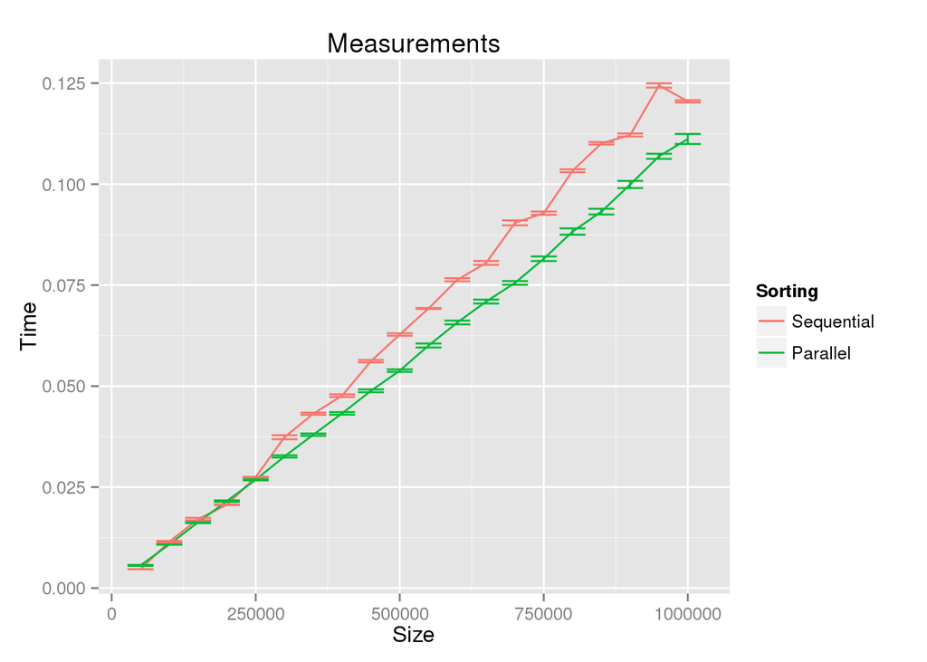

With the regression line:

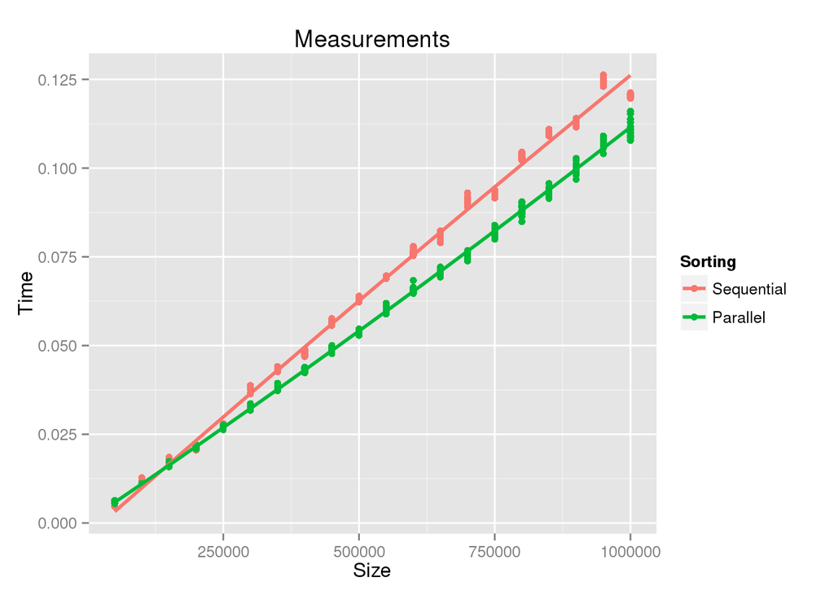

For array size over **300K**, the parallel version outperforms the sequential one

#### Analyzing the number of threads in the parallel version

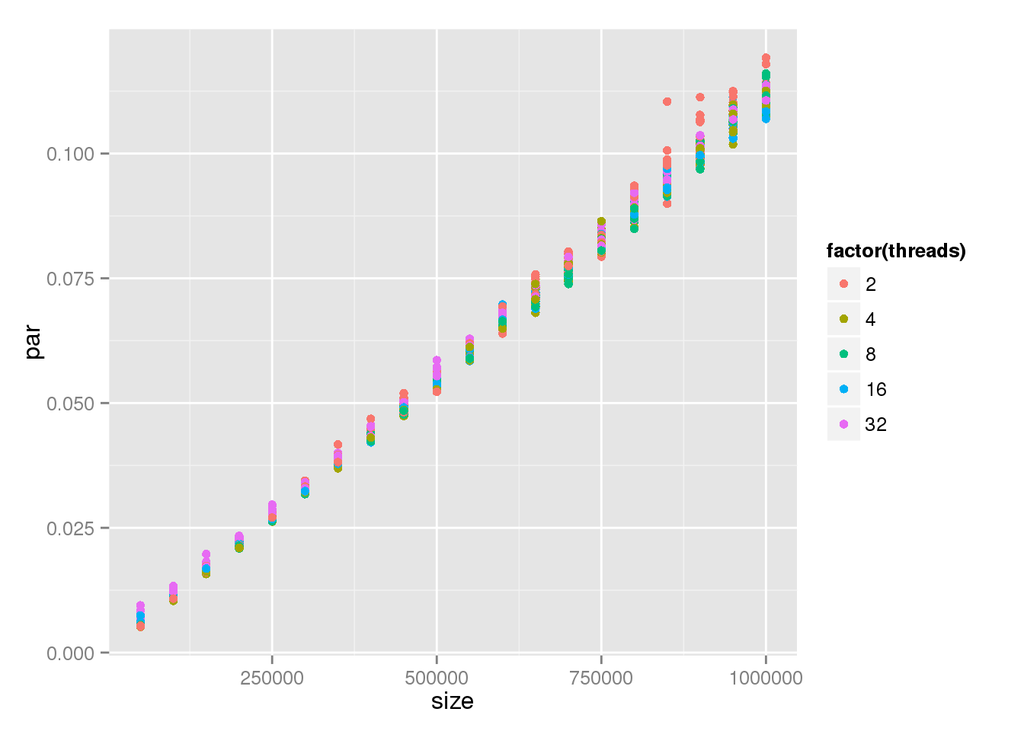

Just focusing on 4 and 8 threads:

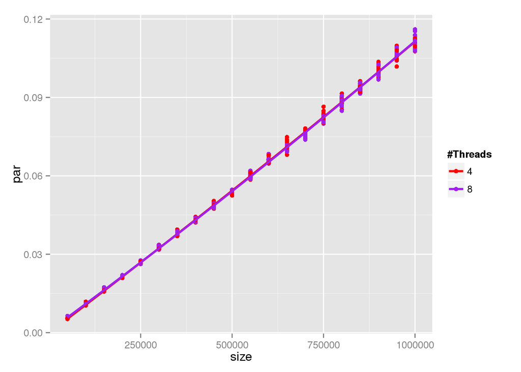

For now it is not clear who is the winner.. let’s go for larger arrays..

### Large values

The results:

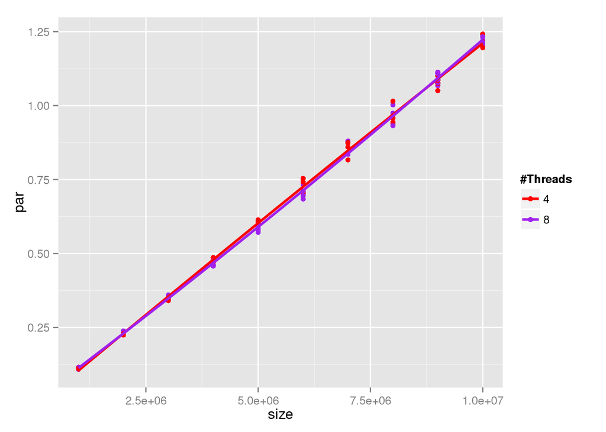

When the size goes large, the best number of threads tends to be **8** which is the double of the number of logical cores.

## Conclusion

The sequential and the parallel version should be used together to obtain the maximum performance for any input size. The selection of the thread level should be done according the underlying hardware.

## Perspective

- Use `taskset` to run on specific processor.
- Study the effect of compiler optimization.
- Try again the first timer
- Try 2nd timer with the clock CLOCK_PROCESS_CPUTIME_ID
- Change the type of data structure : int, float, ..
- Enable/Disable Hyperthreading
- Measure the memory usage